# Context:

An online news portal aims to expand its business by acquiring new subscribers. Every visitor to the website takes certain actions based on their interest. The company plans to analyze these interests and wants to determine whether a new feature will be effective or not. Companies often analyze users' responses to two variants of a product to decide which of the two variants is more effective. This experimental technique is known as a/b testing that is used to determine whether a new feature attracts users based on a chosen metric.

# Objective:

Perform statistical analysis of business data to answer the questions:

1. Explore the dataset and extract insights using Exploratory Data Analysis.
2. Do the users spend more time on the new landing page than the old landing page?
3. Is the conversion rate (the proportion of users who visit the landing page and get converted) for the new page greater than the conversion rate for the old page?
4. Does the converted status depend on the preferred language?
5. Is the mean time spent on the new page same for the different language users?

Note: Significance level of 0.05 is consideredfor all tests.

# Data Dictionary:

1. user_id - This represents the user ID of the person visiting the website.
2. group - This represents whether the user belongs to the first group (control) or the second group (treatment).
3. landing_page - This represents whether the landing page is new or old.
4. time_spent_on_the_page - This represents the time (in minutes) spent by the user on the landing page.
5. converted - This represents whether the user gets converted to a subscriber of the news portal or not.
6. language_preferred - This represents the language chosen by the user to view the landing page.

# Import the neccessary packages

```python
import warnings
warnings.filterwarnings('ignore')
import pandas as pd  # library used for data manipulation and analysis
import numpy as np  # library used for working with arrays
import matplotlib.pyplot as plt  # library for plots and visualizations
import seaborn as sns  # library for visualizations

%matplotlib inline

import scipy.stats as stats  # this library contains a large number of probability distributions as well as a growing library of statistical functions
```

# Read the dataset

```python
data = pd.read_csv('abtest.csv')
data.head() # displays the first five rows
```

|  | user_id | group | landing_page | time_spent_on_the_page | converted | language_preferred |
| --- | --- | --- | --- | --- | --- | --- |
| 0 | 546592 | control | old | 3.48 | no | Spanish |
| 1 | 546468 | treatment | new | 7.13 | yes | English |
| 2 | 546462 | treatment | new | 4.40 | no | Spanish |
| 3 | 546567 | control | old | 3.02 | no | French |
| 4 | 546459 | treatment | new | 4.75 | yes | Spanish |

```python
data.tail() # displays the last five rows
```

|  | user_id | group | landing_page | time_spent_on_the_page | converted | language_preferred |
| --- | --- | --- | --- | --- | --- | --- |
| 95 | 546446 | treatment | new | 5.15 | no | Spanish |
| 96 | 546544 | control | old | 6.52 | yes | English |
| 97 | 546472 | treatment | new | 7.07 | yes | Spanish |
| 98 | 546481 | treatment | new | 6.20 | yes | Spanish |
| 99 | 546483 | treatment | new | 5.86 | yes | English |

# Check the shape and data types of the column for the dataset

```python
data.shape
```

```
(100, 6)
```

- The dataset has 100 rows and 6 columns.

```python
data.info()
```

```
<class 'pandas.core.frame.DataFrame'>
RangeIndex: 100 entries, 0 to 99
Data columns (total 6 columns):
 #   Column                  Non-Null Count  Dtype
---  ------                  --------------  -----
 0   user_id                 100 non-null    int64
 1   group                   100 non-null    object
 2   landing_page            100 non-null    object
 3   time_spent_on_the_page  100 non-null    float64
 4   converted               100 non-null    object
 5   language_preferred      100 non-null    object
dtypes: float64(1), int64(1), object(4)
memory usage: 4.8+ KB
```

# Fixing the data types

- group, landing_page, converted and language_preferred are object type, we can change them to category.
- Converting "object" to "category" reduces the data space used

```python
data["group"]=data["group"].astype("category")
data["landing_page"]=data["landing_page"].astype("category")
data["converted"]=data["converted"].astype("category")
data["language_preferred"]=data["language_preferred"].astype("category")
```

```python
data.info()
```

```
<class 'pandas.core.frame.DataFrame'>
RangeIndex: 100 entries, 0 to 99
Data columns (total 6 columns):
 #   Column                  Non-Null Count  Dtype
---  ------                  --------------  -----
 0   user_id                 100 non-null    int64
 1   group                   100 non-null    category
 2   landing_page            100 non-null    category
 3   time_spent_on_the_page  100 non-null    float64
 4   converted               100 non-null    category
 5   language_preferred      100 non-null    category
dtypes: category(4), float64(1), int64(1)
memory usage: 2.6 KB
```

- As we can see the memory usage has decreased after the coversion from 4.8+ KB to 2.6 KB

# Statistical summary for the dataset.

```python
data.describe()
```

|  | user_id | time_spent_on_the_page |
| --- | --- | --- |
| count | 100.000000 | 100.000000 |
| mean | 546517.000000 | 5.377800 |
| std | 52.295779 | 2.378166 |
| min | 546443.000000 | 0.190000 |
| 25% | 546467.750000 | 3.880000 |
| 50% | 546492.500000 | 5.415000 |
| 75% | 546567.250000 | 7.022500 |
| max | 546592.000000 | 10.710000 |

```python
data.describe(include=["category"])
```

|  | group | landing_page | converted | language_preferred |
| --- | --- | --- | --- | --- |
| count | 100 | 100 | 100 | 100 |
| unique | 2 | 2 | 2 | 3 |
| top | control | new | yes | French |
| freq | 50 | 50 | 54 | 34 |

# Checking for missing value

```python
data.isnull().sum()
```

```
user_id                   0
group                     0
landing_page              0
time_spent_on_the_page    0
converted                 0
language_preferred        0
dtype: int64
```

- There are no missing value in the data.

# Q1. Exploratory Data Analysis

```python
# Let us write a function that will help us create a boxplot and histogram for any input numerical variable.
# This function takes the numerical column as the input and returns the boxplots and histograms for the variable.
# This helps us write faster and cleaner code.

def histogram_boxplot(feature, figsize=(15,10)):
    f2, (ax_box2, ax_hist2) = plt.subplots(nrows = 2, # Number of rows of the subplot grid= 2
                                           sharex = True, # x-axis will be shared among all subplots
                                           gridspec_kw = {"height_ratios": (.25, .75)},
                                           figsize = figsize
                                           ) # creating the 2 subplots
    sns.boxplot(feature, ax=ax_box2, showmeans=True, color='red') # create boxplot
    sns.histplot(feature, ax=ax_hist2,edgecolor = None, kde=False) # For histogram
    ax_hist2.axvline(np.mean(feature), color='g', linestyle='--') # Add mean to the histogram
    ax_hist2.axvline(np.median(feature), color='black', linestyle='-') # Add median to the histogram
```

# Observation on the time spent on the page

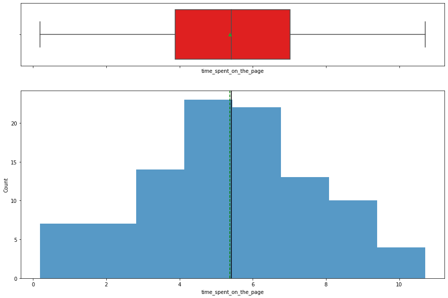

```python
histogram_boxplot(data["time_spent_on_the_page"])
```

- Mean time spent on the page by users is 5.37
- There are no outliers present in the data.

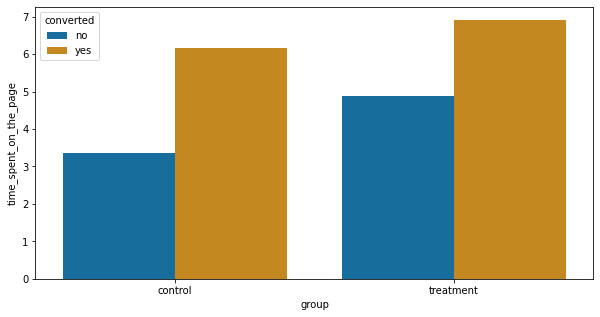

```python
plt.figure(figsize=(10,5))
sns.barplot(data=data, x='group', y='time_spent_on_the_page', hue=data['converted'], ci=None, palette="colorblind")
plt.show()
```

- Converted users in both group spend more time on the landing page.

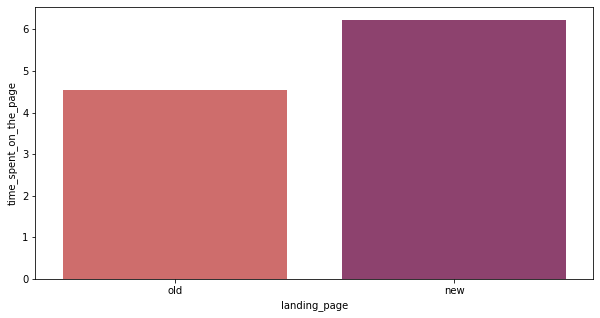

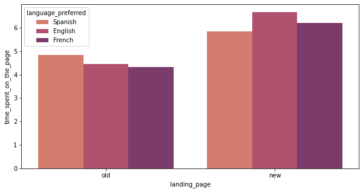

```python
plt.figure(figsize=(10,5))
sns.barplot(data=data, x='landing_page', y='time_spent_on_the_page', ci=None, palette='flare')
plt.savefig('gat2.png', dpi=300)
plt.show()

plt.figure(figsize=(10,5))
sns.barplot(data=data, x='landing_page', y='time_spent_on_the_page', palette='flare',
            hue=data['language_preferred'], ci=None)
plt.show()
```

- Users who land on the new page spend more time on the page than users who land on the old page.
- Users with English as preferred language spend the most time on the new page and users with Spanish as preferred language spend the most time on the old page.

# Observation on Converted

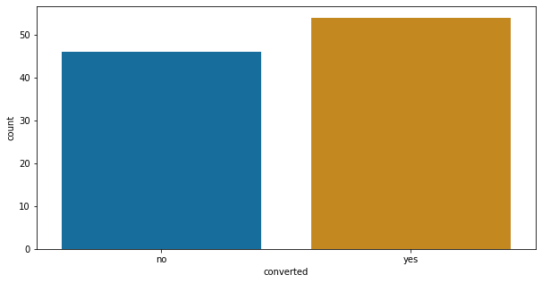

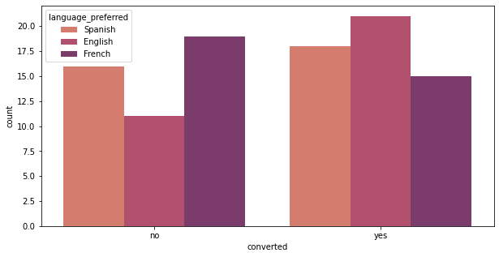

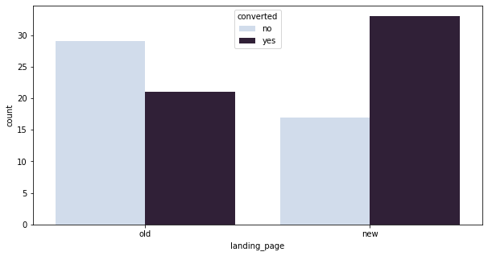

```python
plt.figure(figsize=(10,5))
sns.countplot(data["converted"], palette="colorblind")
plt.savefig('box31.png', dpi=300)
plt.show()

plt.figure(figsize=(10,5))
sns.countplot(data["converted"], hue=data["language_preferred"], palette="flare")
plt.savefig('box32.png', dpi=300)
plt.show()

plt.figure(figsize=(10,5))
sns.countplot(data["landing_page"], hue=data["converted"], palette="ch:s=.40,rot=-.25")
plt.savefig('box33.png', dpi=300)
plt.show()
```

- In general, there are more converted users.
- Users who prefer to view in English have the highest rate of converted users.
- Users who prefer to view in French have the highest rate of non-converted users.
- Conversion rate for the new page us greater than the conversion rate for the old page.

# Observations on Language Preferred

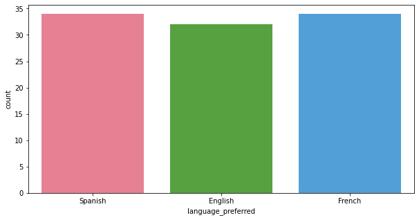

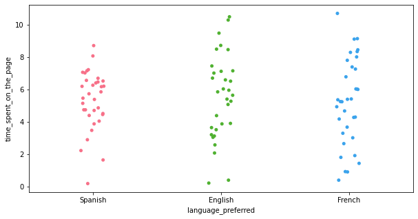

```python
plt.figure(figsize=(10,5))
sns.countplot(data["language_preferred"], palette="husl")
plt.savefig('car1.png', dpi=300)
plt.show()

plt.figure(figsize=(10,5))
sns.stripplot(data=data, x="language_preferred", y="time_spent_on_the_page", palette="husl")
plt.savefig('car2.png', dpi=300)
plt.show()
```

# Q2. Do the user spend more time on the new landing page than the old landing page?

Hypothesis Formula;

> $H_0:\mu_{new}=\mu_{old}$ (Users don't spend more time on the new landing page)

> $H_a:\mu_{new}>\mu_{old}$ (Users spend more time on the new landing page)

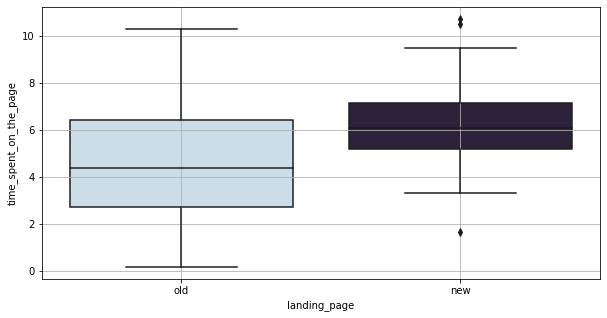

```python
plt.figure(figsize=(10,5))
sns.boxplot(x='landing_page', y='time_spent_on_the_page', data=data, palette="ch:s=.25,rot=-.25")
plt.grid()
plt.savefig('moto.png', dpi=300)
plt.show()
```

```python
# perfom two independent sample t-test
from scipy.stats import ttest_rel

t, p_value  = stats.ttest_rel(time_spent_split['time_spent_on_the_page_new'],time_spent_split['time_spent_on_the_page_old'], alternative = 'greater')  #Performing a paired t-test

#print(t, p_value)
print ('The T statistic is:',t,'\n''The pvalue is :',p_value)
```

[output not shown]

```
The T statistic is: 3.6700490533622028
The pvalue is : 0.00029910900937037973
```

- Since the p- value is much more less than the level of significance ( 𝛼 ) = 0.05, we REJECT the Null Hypothesis. Hence, we have enough statistical evidence/ significance to conclude that the users spend more time on the new landing page.

# Q3. Is the conversion rate for the new page greater than the conversion rate for the old page?

Hypothesis Formula;

> $H_0:\mu_{new}=\mu_{old}$ (Conversion rate for the new page equals the conversion rate for the old page)

> $H_a:\mu_{new}>\mu_{old}$ (Conversion rate for the new page greater than conversion rate for the old page)

# Let's test whether the Z-test assumptions are satisfied or not

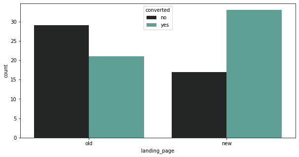

```python
plt.figure(figsize=(10,5))
sns.countplot(data['landing_page'], hue=data['converted'], palette='dark:#5A9')
plt.savefig('keke.png', dpi=300)
plt.show()
```

- Binomally distributed population - Yes, a user is either converted or not..
- Random sampling from the population - Yes, we are informed that the collected sample is a simple random sample.
- Can the binomial distribution approximated to normal distribution - Yes. For binary data, CLT works slower than usual. The standard thing is to check whether np and n(1-p) are greater than or equal to 10. Here, n and p refer to the sample size and sample proportion respectively.
- $np_1 = 50cdot \frac{33}{50} =33 \geq 10\\ n(1-p_1) = 50 \cdot \frac{50-33}{50} =17 \geq 10 \\ np_2 = 50\cdot \frac{21}{50} =21 \geq 10\\ n(1-p_2) = 50 \cdot \frac{50-21}{29} =29 \geq 10 $

```python
#perfom two independent sample t-test

converted_old = data[data['landing_page'] == 'old'][data['converted'] == 'yes']['converted'].count()#number of converted users for old landing page
converted_new = data[data['landing_page'] == 'new'][data['converted'] == 'yes']['converted'].count()#number of converted users for new landing page
print('The number of converted users for new landing page and old landing page are {0} and {1} respectively'.format(converted_new,converted_old))
n_old_landing_page = data[data['landing_page'] == 'old']['converted'].count()#number of users for old landing page
n_new_landing_page = data[data['landing_page'] == 'new']['converted'].count()#number of users for new landing page
print('The number of users for new landing page and old landing page are {0} and {1} respectively'.format(n_new_landing_page,n_old_landing_page))
```

```
The number of converted users for new landing page and old landing page are 33 and 21 respectively
The number of users for new landing page and old landing page are 50 and 50 respectively
```

```python
print(f' The proportion of converted users in new landing page and old landing page = {round(33/50,2)}% and {round(21/50,2)}% respectively')
```

[output not shown]